# Modelo Regressao Linear Simples

Regina Bernal

01/06/2023

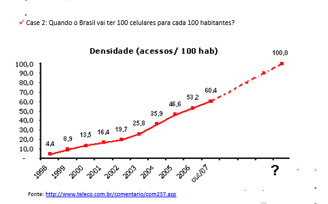

Figura 1

```
##    ano tempo densidade
## 1 1998     1       4.4
## 2 1999     2       8.9
## 3 2000     3      13.5
## 4 2001     4      16.4
## 5 2002     5      19.7
## 6 2003     6      25.8
## 7 2004     7      35.9
## 8 2005     8      46.6
## 9 2006     9      53.2
```

Grafico de dispersao e ajustar a regressao linear

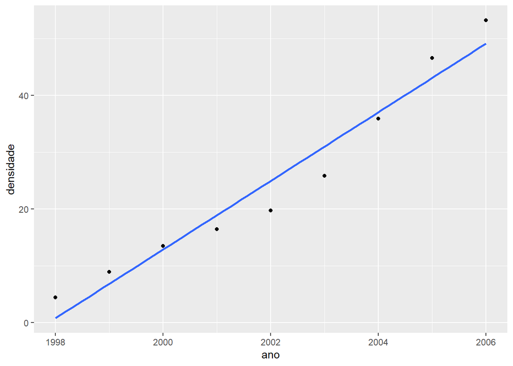

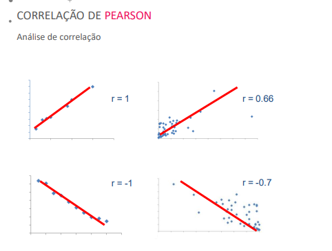

Figura 2.

```
## [1] 0.9760124
```

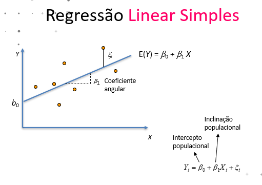

Figura 3.

```
##
## Call:
## lm(formula = df$densidade ~ df$tempo)
##
## Residuals:
##    Min     1Q Median     3Q    Max
## -5.233 -2.492  0.650  3.542  4.100
##
## Coefficients:
##             Estimate Std. Error t value   Pr(>|t|)
## (Intercept)  -5.2750     2.8664   -1.84      0.108
## df$tempo      6.0417     0.5094   11.86 0.00000688 ***
## ---
## Signif. codes:  0 '***' 0.001 '**' 0.01 '*' 0.05 '.' 0.1 ' ' 1
##
## Residual standard error: 3.946 on 7 degrees of freedom
## Multiple R-squared:  0.9526, Adjusted R-squared:  0.9458
## F-statistic: 140.7 on 1 and 7 DF,  p-value: 0.000006876
```

Modelo ajustado

densidade = -5.2750 + 6.0417 * tempo

O aumento medio da densidade eh 6.04% ao ano

Previsao da densidade para tempo = 10,11,12 …

```
##      Min.   1st Qu.    Median      Mean   3rd Qu.      Max.
## -5.233500 -2.491800  0.649900 -0.000167  3.541400  4.099700
```

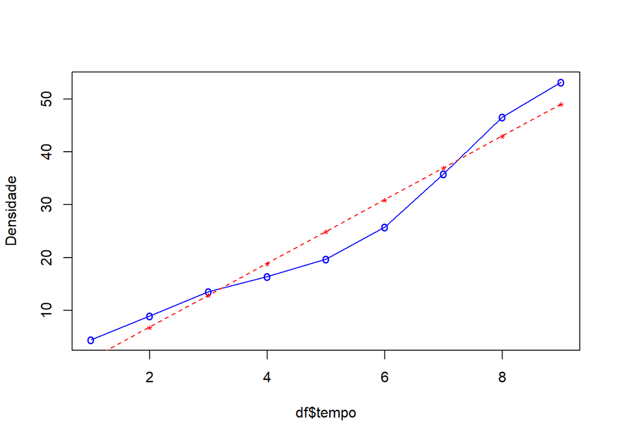

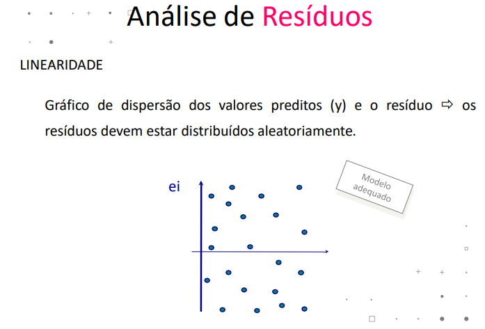

O grafico de residuo mostrou que a relação entre a densidade e o tempo não eh linear. Logo, o modelo ajustado não esta adequado ao conjunto de dados

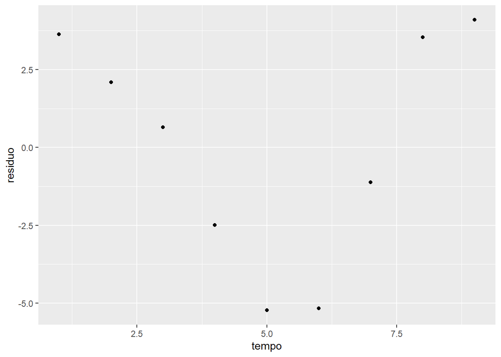

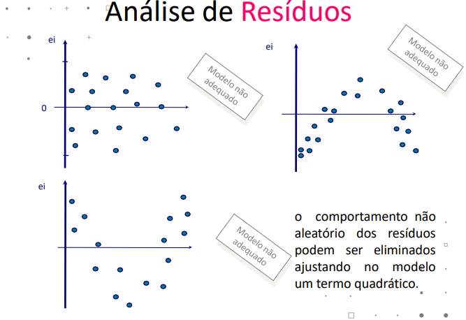

Figura 5

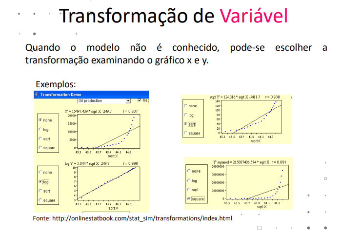

Transformar a relacao nao linear em linear

```
##
## Call:
## lm(formula = df$lndensidade ~ df$tempo)
##
## Residuals:
##      Min       1Q   Median       3Q      Max
## -0.32813 -0.00483  0.01451  0.08722  0.21477
##
## Coefficients:
##             Estimate Std. Error t value   Pr(>|t|)
## (Intercept)   1.5206     0.1226   12.40 0.00000511 ***
## df$tempo      0.2891     0.0218   13.26 0.00000324 ***
## ---
## Signif. codes:  0 '***' 0.001 '**' 0.01 '*' 0.05 '.' 0.1 ' ' 1
##
## Residual standard error: 0.1688 on 7 degrees of freedom
## Multiple R-squared:  0.9617, Adjusted R-squared:  0.9563
## F-statistic: 175.9 on 1 and 7 DF,  p-value: 0.000003239
```

Calcular o valor previsto do modelo densidade = y = 1.5206 + 0.2891*df$tempo exp(y)

Grafico da densidade e os valores previstos dos dois modelos

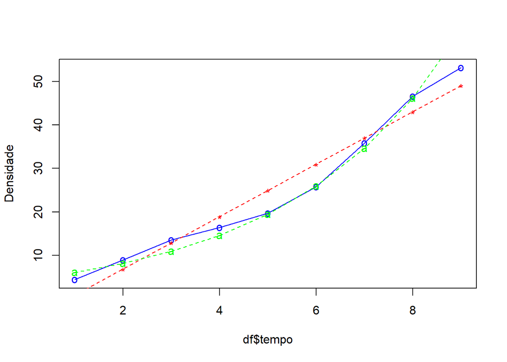

Faca a projecao do modelo 2. Quando o Brasil teria 100%?

previsto_ln(10) = exp(1.5206 + 0.2891*10) = 82.4012 previsto_ln(11) = exp(1.5206 + 0.2891*11) = 110.0242

Conclusao: A previsão do modelo mostra que em menos de dois anos o Brasil teria 100%.

Modelo polinomial de ordem2 densidade = a + b1*ano + b2*ano*ano

```
##
## Call:
## lm(formula = df$densidade ~ df$tempo + I(df$tempo^2))
##
## Residuals:
##     Min      1Q  Median      3Q     Max
## -2.1411 -1.3636  0.3110  0.8424  2.2924
##
## Coefficients:
##               Estimate Std. Error t value Pr(>|t|)
## (Intercept)     4.5405     2.3628   1.922  0.10304
## df$tempo        0.6878     1.0849   0.634  0.54951
## I(df$tempo^2)   0.5354     0.1058   5.060  0.00231 **
## ---
## Signif. codes:  0 '***' 0.001 '**' 0.01 '*' 0.05 '.' 0.1 ' ' 1
##
## Residual standard error: 1.857 on 6 degrees of freedom
## Multiple R-squared:  0.991,  Adjusted R-squared:  0.988
## F-statistic: 330.4 on 2 and 6 DF,  p-value: 0.0000007288
```

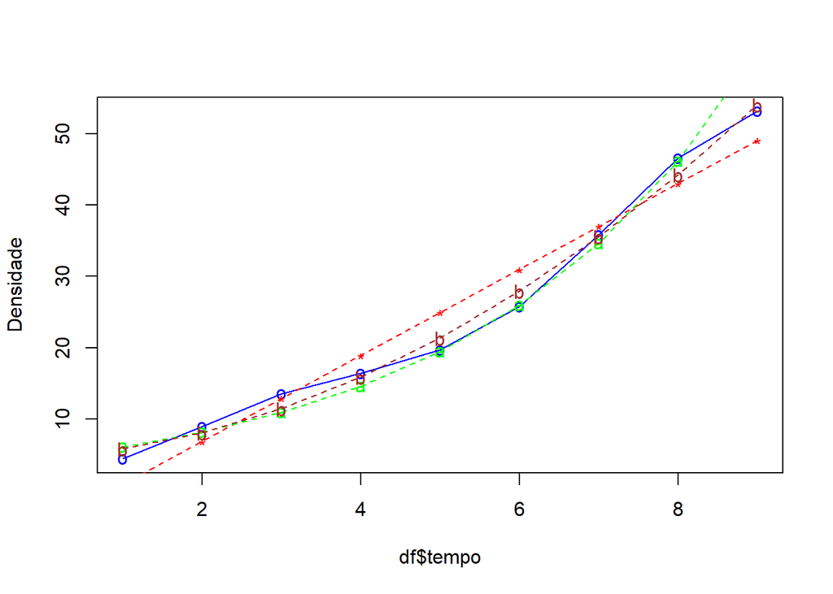

Fazer a previsao da densidade usando o modelo polinomial de ordem 2. Quando o Brasil teria 100%?

previsao(10) = 4.5405 + 0.6878*10 + 0.5354*10*10 = 64.9585 previsao(11) = 4.5405 + 0.6878*11 + 0.5354*11*11 = 76.8897 previsao(12) = 4.5405 + 0.6878*12 + 0.5354*12*12 = 89.8917 previsao(13) = 4.5405 + 0.6878*13 + 0.5354*13*13 = 103.9645